# *Introduction to Statistical Learning Using Python*

- **LAB1: Introduction to Python**
  - Basic Elements of Python
  - Working with Lists
  - IF Statement
  - FOR and While Loops
  - Functions
- **LAB2: Dealing With Data**
  - Importing and Manipulating Data
  - Dealing with Missing Values
  - Summary Statistics
  - Understanding Data
  - Data Interpolation
  - Visualizing Data
- **LAB3: Real World Data**
  - Logistic Regression
  - Linear and Quadratic Discriminant Analysis
  - Classification Trees, Random Forest

## *Getting Started with Pandas*

##### Panda is a library, which contains high-level data structure that designed to make data analysis fast and easy in Python.

- Main two type structures:
  - *Series*
  - *DataFrame*

## Series

- Series is a one dimensional array-like object containing an array of data and an associated array of data labels, called `index`

```python
from pandas import Series, DataFrame
import pandas as pd
import os
```

```python
obj = Series ([4,7,-5,3])
```

```python
print(obj)
```

```
0    4
1    7
2   -5
3    3
dtype: int64
```

```python
obj.values
```

```
array([ 4,  7, -5,  3], dtype=int64)
```

```python
obj.index
```

```
RangeIndex(start=0, stop=4, step=1)
```

### Selecting Value by index

```python
obj[1]
```

```
7
```

```python
obj[[1,3]]
```

```
1    7
3    3
dtype: int64
```

### Operations with Series

```python
obj[obj>0]
```

```
0    4
1    7
3    3
dtype: int64
```

```python
obj[obj>3]
```

```
0    4
1    7
dtype: int64
```

```python
obj*2
```

```
0     8
1    14
2   -10
3     6
dtype: int64
```

```python
4 in obj.values
```

```
True
```

### DataFrame

- A DataFrame represents spreadsheet -like data structure containing an ordered collection of columns, each of which can be a different value type (numeric, string, etc.)

```python
data= {
       'Student': ["Muhammad Abdullah","Kayli Abernathy","Jacqueline Alvarez",
                    "Daniel Chavez","Aramayis Dallakyan"],
       'UIN' : [925024924,925024924,925024924,915140123,925124214],
       'Graduation_Year' : [2017,2016,2018,2020,2018]
}
frame = DataFrame(data)
```

```python
frame
```

|  | Graduation_Year | Student | UIN |
| --- | --- | --- | --- |
| 0 | 2017 | Muhammad Abdullah | 925024924 |
| 1 | 2016 | Kayli Abernathy | 925024924 |
| 2 | 2018 | Jacqueline Alvarez | 925024924 |
| 3 | 2020 | Daniel Chavez | 915140123 |
| 4 | 2018 | Aramayis Dallakyan | 925124214 |

### Seperating First and Last Name

```python
frame.loc[frame['Student'].index, 'Last_name'] = frame['Student'].str.split().str[-1]
frame.loc[frame['Student'].index, 'First_name'] = frame['Student'].str.split().str[0]
```

```python
frame
```

|  | Graduation_Year | Student | UIN | Last_name | First_name |
| --- | --- | --- | --- | --- | --- |
| 0 | 2017 | Muhammad Abdullah | 925024924 | Abdullah | Muhammad |
| 1 | 2016 | Kayli Abernathy | 925024924 | Abernathy | Kayli |
| 2 | 2018 | Jacqueline Alvarez | 925024924 | Alvarez | Jacqueline |
| 3 | 2020 | Daniel Chavez | 915140123 | Chavez | Daniel |
| 4 | 2018 | Aramayis Dallakyan | 925124214 | Dallakyan | Aramayis |

```python
frame.drop(["Student"],axis=1,inplace= True)
```

```python
frame["First_name"]
```

```
0      Muhammad
1         Kayli
2    Jacqueline
3        Daniel
4      Aramayis
Name: First_name, dtype: object
```

```python
frame[frame["First_name"]=="Aramayis"]
```

|  | Graduation_Year | UIN | Last_name | First_name |
| --- | --- | --- | --- | --- |
| 4 | 2018 | 925124214 | Dallakyan | Aramayis |

### Inserting Data

- Define Directory

```python
os.chdir("C:\Users\dallakyan1988\Documents\Python_Presentation")
```

- Import Data using `read_csv()` function

*`read_csv(filepath, sep=', ', header='infer', names=None, index_col=None, usecols=None,skiprows=None, nrows=None, na_values=None)`*

```python
data1 = pd.read_csv("Orange_data.csv",sep = ",",na_values=' ')
data2 = pd.read_csv("Income.csv",sep = ",")
```

```python
data2.set_index(pd.DatetimeIndex(data2['Date']),inplace = True)
```

```python
data1.head()
```

|  | Month | Year | Per_Capita_Cons | Real_Price |
| --- | --- | --- | --- | --- |
| 0 | 1 | 1995 | 0.280531 | 2.512980 |
| 1 | 2 | 1995 | 0.245859 | 2.541516 |
| 2 | 3 | 1995 | 0.270097 | 2.580534 |
| 3 | 4 | 1995 | 0.246311 | 2.647361 |
| 4 | 5 | 1995 | 0.248911 | 2.681170 |

```python
data2.head()
```

|  | Quarter | Year | Per_Capita_Income | Date |
| --- | --- | --- | --- | --- |
| 1995-03-31 | 1 | 1995 | 13409.87 | 3/31/1995 |
| 1995-06-30 | 2 | 1995 | 13239.51 | 6/30/1995 |
| 1995-09-30 | 3 | 1995 | 13342.37 | 9/30/1995 |
| 1995-12-31 | 4 | 1995 | 13406.83 | 12/31/1995 |
| 1996-03-31 | 1 | 1996 | 13344.17 | 3/31/1996 |

```python
del data2.index.name
```

- It is always good idea to check data types of variables

```python
data1.dtypes
```

```
Month                int64
Year                 int64
Per_Capita_Cons    float64
Real_Price         float64
dtype: object
```

```python
data2.dtypes
```

```
Quarter                int64
Year                   int64
Per_Capita_Income    float64
Date                  object
dtype: object
```

- Dealing with missing values
- Function to count missing values

```python
def missing_count(data):
    missing = pd.DataFrame(data.isnull().sum(),columns=['Total_missing'])
    return missing
```

```python
missing_count(data1)
```

|  | Total_missing |
| --- | --- |
| Month | 0 |
| Year | 0 |
| Per_Capita_Cons | 9 |
| Real_Price | 0 |

```python
missing_count(data2)
```

|  | Total_missing |
| --- | --- |
| Quarter | 0 |
| Year | 0 |
| Per_Capita_Income | 0 |
| Date | 0 |

```python
data1[data1["Per_Capita_Cons"].isnull()==True]
```

|  | Month | Year | Per_Capita_Cons | Real_Price |
| --- | --- | --- | --- | --- |
| 6 | 7 | 1995 | NaN | 2.673106 |
| 21 | 10 | 1996 | NaN | 2.969037 |
| 38 | 3 | 1998 | NaN | 2.767408 |
| 49 | 2 | 1999 | NaN | 3.179427 |
| 63 | 4 | 2000 | NaN | 3.152969 |
| 68 | 9 | 2000 | NaN | 3.134388 |
| 76 | 5 | 2001 | NaN | 3.164449 |
| 84 | 1 | 2002 | NaN | 3.141355 |
| 88 | 5 | 2002 | NaN | 3.158666 |

- Possible Solutions
  - Drop all **`NAN`** values (Not always the best)

```python
cleaned = data1.dropna()
```

```python
missing_count(cleaned)
```

|  | Total_missing |
| --- | --- |
| Month | 0 |
| Year | 0 |
| Per_Capita_Cons | 0 |
| Real_Price | 0 |

#### NOTE:You have several options for dropping. You can drop if

```
* all raw is **`NAN`**
* all column is **`NAN`**
* or by threshhold
```

```python
from numpy import nan as NA
example = DataFrame([[2.,6.5,3.],[1.,NA,NA],[NA,NA,NA],[NA,4.,4.]])
```

```python
example
```

|  | 0 | 1 | 2 |
| --- | --- | --- | --- |
| 0 | 2.0 | 6.5 | 3.0 |
| 1 | 1.0 | NaN | NaN |
| 2 | NaN | NaN | NaN |
| 3 | NaN | 4.0 | 4.0 |

```python
example.dropna()
```

|  | 0 | 1 | 2 |
| --- | --- | --- | --- |
| 0 | 2.0 | 6.5 | 3.0 |

```python
example.dropna(how="all")
```

|  | 0 | 1 | 2 |
| --- | --- | --- | --- |
| 0 | 2.0 | 6.5 | 3.0 |
| 1 | 1.0 | NaN | NaN |
| 3 | NaN | 4.0 | 4.0 |

```python
example.dropna(thresh=2)
```

|  | 0 | 1 | 2 |
| --- | --- | --- | --- |
| 0 | 2.0 | 6.5 | 3.0 |
| 3 | NaN | 4.0 | 4.0 |

**Method 2**

- Fill **`NAN`** values with mean

```python
last_item_filled=data1.fillna(method='ffill')
```

```python
mean_filled=data1.fillna(data1['Per_Capita_Cons'].mean())
```

```python
data1[data1["Per_Capita_Cons"].isnull()==True]
```

|  | Month | Year | Per_Capita_Cons | Real_Price |
| --- | --- | --- | --- | --- |
| 6 | 7 | 1995 | NaN | 2.673106 |
| 21 | 10 | 1996 | NaN | 2.969037 |
| 38 | 3 | 1998 | NaN | 2.767408 |
| 49 | 2 | 1999 | NaN | 3.179427 |
| 63 | 4 | 2000 | NaN | 3.152969 |
| 68 | 9 | 2000 | NaN | 3.134388 |
| 76 | 5 | 2001 | NaN | 3.164449 |
| 84 | 1 | 2002 | NaN | 3.141355 |
| 88 | 5 | 2002 | NaN | 3.158666 |

```python
last_item_filled.ix[data1[data1["Per_Capita_Cons"].isnull()==True].index,:]
```

|  | Month | Year | Per_Capita_Cons | Real_Price |
| --- | --- | --- | --- | --- |
| 6 | 7 | 1995 | 0.236881 | 2.673106 |
| 21 | 10 | 1996 | 0.241302 | 2.969037 |
| 38 | 3 | 1998 | 0.251118 | 2.767408 |
| 49 | 2 | 1999 | 0.287569 | 3.179427 |
| 63 | 4 | 2000 | 0.263581 | 3.152969 |
| 68 | 9 | 2000 | 0.249545 | 3.134388 |
| 76 | 5 | 2001 | 0.253853 | 3.164449 |
| 84 | 1 | 2002 | 0.259314 | 3.141355 |
| 88 | 5 | 2002 | 0.246272 | 3.158666 |

```python
mean_filled.ix[data1[data1["Per_Capita_Cons"].isnull()==True].index,:]
```

|  | Month | Year | Per_Capita_Cons | Real_Price |
| --- | --- | --- | --- | --- |
| 6 | 7 | 1995 | 0.251914 | 2.673106 |
| 21 | 10 | 1996 | 0.251914 | 2.969037 |
| 38 | 3 | 1998 | 0.251914 | 2.767408 |
| 49 | 2 | 1999 | 0.251914 | 3.179427 |
| 63 | 4 | 2000 | 0.251914 | 3.152969 |
| 68 | 9 | 2000 | 0.251914 | 3.134388 |
| 76 | 5 | 2001 | 0.251914 | 3.164449 |
| 84 | 1 | 2002 | 0.251914 | 3.141355 |
| 88 | 5 | 2002 | 0.251914 | 3.158666 |

**Method 3**

- Interpolation (Not usable for all variables) Interpolation is method to create a function based on fixed data points which can be evaluated anywhere within the domain defined by the given data using **linear**, **Cubic spline** interpolation.

```python
import numpy as np
import matplotlib.pyplot as plt
from scipy import interpolate
from scipy.interpolate import Rbf,InterpolatedUnivariateSpline
```

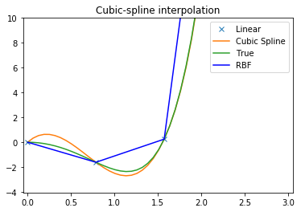

```python
x = np.arange(0, 2*np.pi+np.pi/4, 2*np.pi/8)
y = 0.8*np.power(x,5)- 3*np.power(x,2)
tck = interpolate.splrep(x, y, s=0)
xnew = np.arange(0, 2*np.pi, np.pi/50)
ynew = interpolate.splev(xnew, tck, der=0)

plt.figure()
plt.plot(x, y, 'x', xnew, ynew, xnew, 0.8*np.power(xnew,5)- 3* np.power(xnew,2), x, y, 'b')
plt.legend(['Linear', 'Cubic Spline', 'True','RBF'])
plt.axis([-0.05, 3.05, -4.05, 10])
plt.title('Cubic-spline interpolation')
plt.show()
```

#### Linear and Cubic Spline for Orange data

```python
linear_interpolated= data1['Per_Capita_Cons'].interpolate(method='linear')
spline_interpolated= data1['Per_Capita_Cons'].interpolate(method='spline',order=3)
```

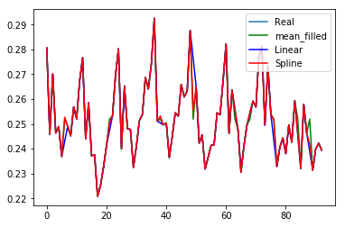

```python
plt.figure
plt.plot(xi, data1["Per_Capita_Cons"],xi, mean_filled["Per_Capita_Cons"],'g',xi,linear_interpolated,'b',xi,spline_interpolated,'r')
plt.legend(["Real",'mean_filled','Linear',"Spline"])
plt.show()
```

```python
data1['Per_Capita_Cons'] = spline_interpolated
```

#### Notice that Income data and Consumption data have different time frequences.

- We want to match the frequences of Income and Consumption

```python
data2.head()
```

|  | Quarter | Year | Per_Capita_Income | Date |
| --- | --- | --- | --- | --- |
| 1995-03-31 | 1 | 1995 | 13409.87 | 3/31/1995 |
| 1995-06-30 | 2 | 1995 | 13239.51 | 6/30/1995 |
| 1995-09-30 | 3 | 1995 | 13342.37 | 9/30/1995 |
| 1995-12-31 | 4 | 1995 | 13406.83 | 12/31/1995 |
| 1996-03-31 | 1 | 1996 | 13344.17 | 3/31/1996 |

```python
data2.tail()
```

|  | Quarter | Year | Per_Capita_Income | Date |
| --- | --- | --- | --- | --- |
| 2001-09-30 | 3 | 2001 | 14949.23 | 9/30/2001 |
| 2001-12-31 | 4 | 2001 | 14552.38 | 12/31/2001 |
| 2002-03-31 | 1 | 2002 | 14921.27 | 3/31/2002 |
| 2002-06-30 | 2 | 2002 | 15034.68 | 6/30/2002 |
| 2002-09-30 | 3 | 2002 | 15153.60 | 9/30/2002 |

- To start interpolation from Quartely frequency to Monthly frequency, first we need to proper index

```python
from pandas import datetime
period = 7*12 + 9-2
index = pd.date_range('3/1/1995', periods=period, freq='m')
```

```
1995-03-31    13409.870000
1995-04-30    13301.960115
1995-05-31    13248.374849
1995-06-30    13239.510000
1995-07-31    13261.310071
1995-08-31    13300.635785
1995-09-30    13342.370000
1995-10-31    13377.273067
1995-11-30    13399.240400
1995-12-31    13406.830000
Freq: M, Name: Per_Capita_Income, dtype: float64
```

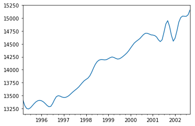

```python
upsampled = data2["Per_Capita_Income"].resample('M')
interpolated = upsampled.interpolate(method='spline', order=3)
print(interpolated.head(10))
interpolated.plot()
plt.show()
```

```
1995-03-31    13409.870000
1995-04-30    13353.083333
1995-05-31    13296.296667
1995-06-30    13239.510000
1995-07-31    13273.796667
1995-08-31    13308.083333
1995-09-30    13342.370000
1995-10-31    13363.856667
1995-11-30    13385.343333
1995-12-31    13406.830000
Freq: M, Name: Per_Capita_Income, dtype: float64
```

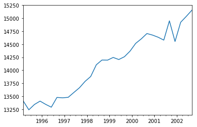

```python
interpolated = upsampled.interpolate(method='linear', order=3)
print(interpolated.head(10))
interpolated.plot()
plt.show()
```

```python
interpolated=pd.DataFrame(interpolated)
interpolated.head()
```

|  | Per_Capita_Income |
| --- | --- |
| 1995-03-31 | 13409.870000 |
| 1995-04-30 | 13353.083333 |
| 1995-05-31 | 13296.296667 |
| 1995-06-30 | 13239.510000 |
| 1995-07-31 | 13273.796667 |

### Now we want to merge Interpolated income data with Orange consumption data

```python
data1.head()
```

|  | Month | Year | Per_Capita_Cons | Real_Price |
| --- | --- | --- | --- | --- |
| 0 | 1 | 1995 | 0.280531 | 2.512980 |
| 1 | 2 | 1995 | 0.245859 | 2.541516 |
| 2 | 3 | 1995 | 0.270097 | 2.580534 |
| 3 | 4 | 1995 | 0.246311 | 2.647361 |
| 4 | 5 | 1995 | 0.248911 | 2.681170 |

```python
period = 7*12 + 9
data1index = pd.date_range('1/1/1995', periods=period, freq='m')
```

```python
data1.set_index(data1index,inplace = True)
```

```python
data1.head()
```

|  | Month | Year | Per_Capita_Cons | Real_Price |
| --- | --- | --- | --- | --- |
| 1995-01-31 | 1 | 1995 | 0.280531 | 2.512980 |
| 1995-02-28 | 2 | 1995 | 0.245859 | 2.541516 |
| 1995-03-31 | 3 | 1995 | 0.270097 | 2.580534 |
| 1995-04-30 | 4 | 1995 | 0.246311 | 2.647361 |
| 1995-05-31 | 5 | 1995 | 0.248911 | 2.681170 |

#### Merge by index

```python
Merged =DataFrame(pd.merge(data1,interpolated,left_index=True,right_index=True))
```

```python
Merged.head()
```

|  | Month | Year | Per_Capita_Cons | Real_Price | Per_Capita_Income |
| --- | --- | --- | --- | --- | --- |
| 1995-03-31 | 3 | 1995 | 0.270097 | 2.580534 | 13409.870000 |
| 1995-04-30 | 4 | 1995 | 0.246311 | 2.647361 | 13353.083333 |
| 1995-05-31 | 5 | 1995 | 0.248911 | 2.681170 | 13296.296667 |
| 1995-06-30 | 6 | 1995 | 0.236881 | 2.662763 | 13239.510000 |
| 1995-07-31 | 7 | 1995 | 0.252691 | 2.673106 | 13273.796667 |

```python
Merged=Merged.drop(["Year","Month "],axis=1)
```

```python
Merged.head()
```

|  | Per_Capita_Cons | Real_Price | Per_Capita_Income |
| --- | --- | --- | --- |
| 1995-03-31 | 0.270097 | 2.580534 | 13409.870000 |
| 1995-04-30 | 0.246311 | 2.647361 | 13353.083333 |
| 1995-05-31 | 0.248911 | 2.681170 | 13296.296667 |
| 1995-06-30 | 0.236881 | 2.662763 | 13239.510000 |
| 1995-07-31 | 0.252691 | 2.673106 | 13273.796667 |

```python
Merged.columns
```

[output not shown]

#### Other examples of Merging

```python
df1 = pd.DataFrame({'A': np.random.uniform(size=4),
                     'B': np.random.uniform(size=4),
                     'C': np.random.uniform(size=4),
                     'D': np.random.uniform(size=4)},
                     index=[0, 1, 2, 3])


df2 = pd.DataFrame({'A': np.random.normal(size=4),
                        'B': np.random.normal(size=4),
                        'C': np.random.normal(size=4),
                        'D': np.random.normal(size=4)},
                         index=[4, 5, 6, 7])


df3 = pd.DataFrame({'A':np.random.uniform(size=4),
                     'B': np.random.uniform(size=4),
                     'C': np.random.uniform(size=4),
                     'D': np.random.uniform(size=4)},
                     index=[8, 9, 10, 11])
```

```python
df1
```

|  | A | B | C | D |
| --- | --- | --- | --- | --- |
| 0 | 0.373849 | 0.392643 | 0.236637 | 0.473750 |
| 1 | 0.841594 | 0.470335 | 0.788696 | 0.507633 |
| 2 | 0.684732 | 0.023441 | 0.592588 | 0.088391 |
| 3 | 0.932812 | 0.201915 | 0.231552 | 0.035624 |

```python
df2
```

|  | A | B | C | D |
| --- | --- | --- | --- | --- |
| 4 | 0.145048 | -0.161068 | 0.356442 | 2.032841 |
| 5 | 0.528435 | -0.612351 | -0.166635 | -0.803647 |
| 6 | 1.519046 | 0.843732 | -0.230930 | 1.226998 |
| 7 | 2.545946 | 0.605684 | 2.961073 | 0.321538 |

```python
df3
```

|  | A | B | C | D |
| --- | --- | --- | --- | --- |
| 8 | 0.304821 | 0.558125 | 0.959540 | 0.918874 |
| 9 | 0.711238 | 0.652642 | 0.436962 | 0.390953 |
| 10 | 0.310293 | 0.856860 | 0.352815 | 0.175165 |
| 11 | 0.656995 | 0.743975 | 0.045016 | 0.322504 |

```python
frames = [df1, df2, df3]

result = pd.concat(frames)
```

```python
result
```

|  | A | B | C | D |
| --- | --- | --- | --- | --- |
| 0 | 0.373849 | 0.392643 | 0.236637 | 0.473750 |
| 1 | 0.841594 | 0.470335 | 0.788696 | 0.507633 |
| 2 | 0.684732 | 0.023441 | 0.592588 | 0.088391 |
| 3 | 0.932812 | 0.201915 | 0.231552 | 0.035624 |
| 4 | 0.145048 | -0.161068 | 0.356442 | 2.032841 |
| 5 | 0.528435 | -0.612351 | -0.166635 | -0.803647 |
| 6 | 1.519046 | 0.843732 | -0.230930 | 1.226998 |
| 7 | 2.545946 | 0.605684 | 2.961073 | 0.321538 |
| 8 | 0.304821 | 0.558125 | 0.959540 | 0.918874 |
| 9 | 0.711238 | 0.652642 | 0.436962 | 0.390953 |
| 10 | 0.310293 | 0.856860 | 0.352815 | 0.175165 |
| 11 | 0.656995 | 0.743975 | 0.045016 | 0.322504 |

```python
df4 = pd.DataFrame({'B': np.random.uniform(size=4),
                 'D':np.random.normal(size=4),
                 'F': np.random.normal(size=4)},
                  index=[2, 3, 6, 7])
```

```python
df4
```

|  | B | D | F |
| --- | --- | --- | --- |
| 2 | 0.208523 | 0.729613 | -0.850613 |
| 3 | 0.849497 | -2.118052 | 0.457051 |
| 6 | 0.159290 | 0.675009 | -1.333192 |
| 7 | 0.917792 | -0.643039 | 0.201721 |

```python
df1
```

|  | A | B | C | D |
| --- | --- | --- | --- | --- |
| 0 | 0.373849 | 0.392643 | 0.236637 | 0.473750 |
| 1 | 0.841594 | 0.470335 | 0.788696 | 0.507633 |
| 2 | 0.684732 | 0.023441 | 0.592588 | 0.088391 |
| 3 | 0.932812 | 0.201915 | 0.231552 | 0.035624 |

```python
result = pd.concat([df1, df4], axis=1)
```

```python
result
```

|  | A | B | C | D | B | D | F |
| --- | --- | --- | --- | --- | --- | --- | --- |
| 0 | 0.373849 | 0.392643 | 0.236637 | 0.473750 | NaN | NaN | NaN |
| 1 | 0.841594 | 0.470335 | 0.788696 | 0.507633 | NaN | NaN | NaN |
| 2 | 0.684732 | 0.023441 | 0.592588 | 0.088391 | 0.208523 | 0.729613 | -0.850613 |
| 3 | 0.932812 | 0.201915 | 0.231552 | 0.035624 | 0.849497 | -2.118052 | 0.457051 |
| 6 | NaN | NaN | NaN | NaN | 0.159290 | 0.675009 | -1.333192 |
| 7 | NaN | NaN | NaN | NaN | 0.917792 | -0.643039 | 0.201721 |

```python
result = df1.append(df2)
```

```python
result
```

|  | A | B | C | D |
| --- | --- | --- | --- | --- |
| 0 | 0.373849 | 0.392643 | 0.236637 | 0.473750 |
| 1 | 0.841594 | 0.470335 | 0.788696 | 0.507633 |
| 2 | 0.684732 | 0.023441 | 0.592588 | 0.088391 |
| 3 | 0.932812 | 0.201915 | 0.231552 | 0.035624 |
| 4 | 0.145048 | -0.161068 | 0.356442 | 2.032841 |
| 5 | 0.528435 | -0.612351 | -0.166635 | -0.803647 |
| 6 | 1.519046 | 0.843732 | -0.230930 | 1.226998 |
| 7 | 2.545946 | 0.605684 | 2.961073 | 0.321538 |

- Merging based on key

```python
left = pd.DataFrame({'key': ['A', 'G', 'E', 'C'],
                    'A': np.random.normal(size=4),
                     'B': np.random.normal(size=4)})

right = pd.DataFrame({'key': ['A', 'G', 'E', 'C'],
                      'C': np.random.normal(size=4),
                      'D': np.random.normal(size=4)})

result = pd.merge(left, right, on='key')
```

```python
left
```

|  | A | B | key |
| --- | --- | --- | --- |
| 0 | 0.312712 | 0.154416 | A |
| 1 | -0.004686 | 0.757326 | G |
| 2 | 0.140112 | -1.105813 | E |
| 3 | 0.585586 | 0.056549 | C |

```python
right
```

|  | C | D | key |
| --- | --- | --- | --- |
| 0 | -0.006953 | -0.206162 | A |
| 1 | -1.506147 | -0.227391 | G |
| 2 | 0.746571 | -0.101790 | E |
| 3 | 1.295349 | 0.545622 | C |

```python
result
```

|  | A | B | key | C | D |
| --- | --- | --- | --- | --- | --- |
| 0 | 0.312712 | 0.154416 | A | -0.006953 | -0.206162 |
| 1 | -0.004686 | 0.757326 | G | -1.506147 | -0.227391 |
| 2 | 0.140112 | -1.105813 | E | 0.746571 | -0.101790 |
| 3 | 0.585586 | 0.056549 | C | 1.295349 | 0.545622 |

### Descriptive Statistics

```python
Merged.describe()
```

|  | Per_Capita_Cons | Real_Price | Per_Capita_Income |
| --- | --- | --- | --- |
| count | 91.000000 | 91.000000 | 91.000000 |
| mean | 0.251604 | 2.985879 | 14101.232747 |
| std | 0.014222 | 0.189700 | 577.904771 |
| min | 0.220848 | 2.580534 | 13239.510000 |
| 25% | 0.241476 | 2.818134 | 13477.115000 |
| 50% | 0.249624 | 3.066989 | 14195.660000 |
| 75% | 0.258852 | 3.149477 | 14624.890000 |
| max | 0.292521 | 3.217425 | 15153.600000 |

### Correlation and Covariance Matrix

```python
returns= Merged.pct_change()
```

```python
returns
```

|  | Per_Capita_Cons | Real_Price | Per_Capita_Income |
| --- | --- | --- | --- |
| 1995-03-31 | NaN | NaN | NaN |
| 1995-04-30 | -0.088065 | 0.025897 | -0.004235 |
| 1995-05-31 | 0.010556 | 0.012771 | -0.004253 |
| 1995-06-30 | -0.048331 | -0.006865 | -0.004271 |
| 1995-07-31 | 0.066744 | 0.003884 | 0.002590 |
| 1995-08-31 | -0.014426 | -0.004534 | 0.002583 |
| 1995-09-30 | -0.015499 | -0.004294 | 0.002576 |
| 1995-10-31 | 0.047503 | -0.006622 | 0.001610 |
| 1995-11-30 | -0.018705 | 0.007299 | 0.001608 |
| 1995-12-31 | 0.060453 | 0.016259 | 0.001605 |
| 1996-01-31 | 0.035085 | 0.011480 | -0.001558 |
| 1996-02-29 | -0.117824 | 0.004200 | -0.001560 |
| 1996-03-31 | 0.059415 | 0.008746 | -0.001563 |
| 1996-04-30 | -0.082940 | 0.027413 | -0.001351 |
| 1996-05-31 | 0.002075 | 0.020915 | -0.001353 |
| 1996-06-30 | -0.070485 | 0.022661 | -0.001355 |
| 1996-07-31 | 0.019683 | 0.017862 | 0.004707 |
| 1996-08-31 | 0.033136 | -0.013083 | 0.004685 |
| 1996-09-30 | 0.037158 | -0.006135 | 0.004663 |
| 1996-10-31 | 0.038412 | 0.004250 | -0.000182 |
| 1996-11-30 | 0.010664 | 0.002774 | -0.000182 |
| 1996-12-31 | 0.064247 | -0.000399 | -0.000182 |
| 1997-01-31 | 0.039709 | -0.010075 | 0.000226 |
| 1997-02-28 | -0.143779 | 0.008699 | 0.000226 |
| 1997-03-31 | 0.105674 | -0.014108 | 0.000226 |
| 1997-04-30 | -0.065007 | -0.009998 | 0.002295 |
| 1997-05-31 | -0.001197 | -0.009287 | 0.002289 |
| 1997-06-30 | -0.061609 | -0.010089 | 0.002284 |
| 1997-07-31 | 0.036933 | -0.019236 | 0.002238 |
| 1997-08-31 | 0.042711 | -0.003209 | 0.002233 |
| ... | ... | ... | ... |
| 2000-04-30 | -0.029687 | 0.007654 | 0.002001 |
| 2000-05-31 | -0.031671 | 0.000706 | 0.001997 |
| 2000-06-30 | -0.069189 | 0.005529 | 0.001993 |
| 2000-07-31 | 0.046668 | -0.010958 | 0.002333 |
| 2000-08-31 | 0.034259 | -0.000796 | 0.002328 |
| 2000-09-30 | 0.021191 | -0.000315 | 0.002322 |
| 2000-10-31 | 0.016964 | 0.000844 | -0.000680 |
| 2000-11-30 | -0.009110 | 0.004206 | -0.000680 |
| 2000-12-31 | 0.080434 | -0.004056 | -0.000681 |
| 2001-01-31 | 0.013404 | -0.007513 | -0.000936 |
| 2001-02-28 | -0.112594 | 0.002642 | -0.000937 |
| 2001-03-31 | 0.095206 | -0.000015 | -0.000938 |
| 2001-04-30 | -0.071041 | 0.003043 | -0.001255 |
| 2001-05-31 | -0.008714 | 0.010503 | -0.001256 |
| 2001-06-30 | -0.074579 | 0.009372 | -0.001258 |
| 2001-07-31 | 0.032898 | -0.004374 | 0.008465 |
| 2001-08-31 | 0.015860 | -0.008411 | 0.008394 |
| 2001-09-30 | -0.025869 | -0.001996 | 0.008324 |
| 2001-10-31 | 0.048402 | -0.008253 | -0.008849 |
| 2001-11-30 | -0.027782 | 0.008198 | -0.008928 |
| 2001-12-31 | 0.068820 | -0.007545 | -0.009008 |
| 2002-01-31 | -0.051912 | 0.005888 | 0.008450 |
| 2002-02-28 | -0.055962 | 0.007676 | 0.008379 |
| 2002-03-31 | 0.111183 | -0.005288 | 0.008309 |
| 2002-04-30 | -0.045084 | -0.008578 | 0.002534 |
| 2002-05-31 | -0.018114 | 0.011836 | 0.002527 |
| 2002-06-30 | -0.043096 | 0.010366 | 0.002521 |
| 2002-07-31 | 0.036618 | -0.014565 | 0.002637 |
| 2002-08-31 | 0.009868 | 0.000324 | 0.002630 |
| 2002-09-30 | -0.011510 | -0.017024 | 0.002623 |

91 rows × 3 columns

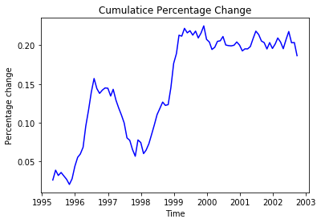

```python
plt.figure()
plt.plot(returns["Real_Price"].cumsum(),"b")
plt.xlabel("Time")
plt.ylabel("Percentage change")
plt.title("Cumulatice Percentage Change")
plt.show()
```

```python
Merged.corr()
```

|  | Per_Capita_Cons | Real_Price | Per_Capita_Income |
| --- | --- | --- | --- |
| Per_Capita_Cons | 1.000000 | -0.154828 | -0.047909 |
| Real_Price | -0.154828 | 1.000000 | 0.806477 |
| Per_Capita_Income | -0.047909 | 0.806477 | 1.000000 |

```python
Merged.cov()
```

|  | Per_Capita_Cons | Real_Price | Per_Capita_Income |
| --- | --- | --- | --- |
| Per_Capita_Cons | 0.000202 | -0.000418 | -0.393761 |
| Real_Price | -0.000418 | 0.035986 | 88.412743 |
| Per_Capita_Income | -0.393761 | 88.412743 | 333973.924309 |

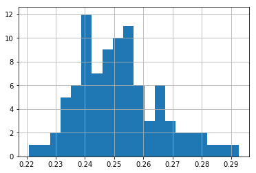

```python
Merged["Per_Capita_Cons"].hist(bins=20)
plt.show()
```

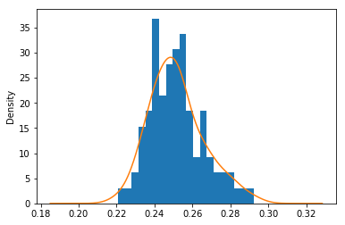

```python
Merged["Per_Capita_Cons"].hist(bins=20,normed= True)
Merged["Per_Capita_Cons"].plot(kind="kde")
plt.show()
```

```python
comp1=np.random.normal(Merged["Per_Capita_Cons"].mean(),Merged["Per_Capita_Cons"].std(),size=200)
values = Series(comp1)
```

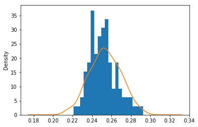

```python
Merged["Per_Capita_Cons"].hist(bins=20,normed= True)
values.plot(kind="kde")
plt.show()
```

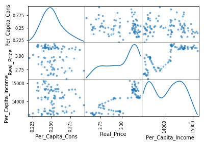

```python
pd.scatter_matrix(Merged, diagonal="kde",alpha=0.5)
plt.show()
```